# **Lab01**

Valeria Salinas-Lopez

2/4/2021

# **R Programming Introduction**

## Adapted from ISLR Chapter 2 Lab: *Introduction to R*

### **Basic Commands**

##### Create objects using the assignment operator (<-, =)

```r
(x <- c(1,3,2,5))
```

```
## [1] 1 3 2 5
```

```r
(y = c(1,4,3))
```

```
## [1] 1 4 3
```

##### Using function length()

```r
length(x)
```

```
## [1] 4
```

```r
length(y)
```

```
## [1] 3
```

###### length() counts the number of observations in each value.

##### Create a sequence

```r
(x=seq(1,10))
```

```
##  [1]  1  2  3  4  5  6  7  8  9 10
```

###### You can acheive the same result by using `(x=c(1:10))` or `(x=1:10)`.

##### Create a sequence with 50 values that are equally spaced

```r
(x=seq(-pi,pi,length=50))
```

```
##  [1] -3.14159265 -3.01336438 -2.88513611 -2.75690784 -2.62867957 -2.50045130
##  [7] -2.37222302 -2.24399475 -2.11576648 -1.98753821 -1.85930994 -1.73108167
## [13] -1.60285339 -1.47462512 -1.34639685 -1.21816858 -1.08994031 -0.96171204
## [19] -0.83348377 -0.70525549 -0.57702722 -0.44879895 -0.32057068 -0.19234241
## [25] -0.06411414  0.06411414  0.19234241  0.32057068  0.44879895  0.57702722
## [31]  0.70525549  0.83348377  0.96171204  1.08994031  1.21816858  1.34639685
## [37]  1.47462512  1.60285339  1.73108167  1.85930994  1.98753821  2.11576648
## [43]  2.24399475  2.37222302  2.50045130  2.62867957  2.75690784  2.88513611
## [49]  3.01336438  3.14159265
```

##### Make y values the same as the x values

```r
y=x
```

##### Using operators (+, -, *, /,^, sqrt())

```r
x+y
```

```
##  [1] -6.2831853 -6.0267288 -5.7702722 -5.5138157 -5.2573591 -5.0009026
##  [7] -4.7444460 -4.4879895 -4.2315330 -3.9750764 -3.7186199 -3.4621633
## [13] -3.2057068 -2.9492502 -2.6927937 -2.4363372 -2.1798806 -1.9234241
## [19] -1.6669675 -1.4105110 -1.1540544 -0.8975979 -0.6411414 -0.3846848
## [25] -0.1282283  0.1282283  0.3846848  0.6411414  0.8975979  1.1540544
## [31]  1.4105110  1.6669675  1.9234241  2.1798806  2.4363372  2.6927937
## [37]  2.9492502  3.2057068  3.4621633  3.7186199  3.9750764  4.2315330
## [43]  4.4879895  4.7444460  5.0009026  5.2573591  5.5138157  5.7702722
## [49]  6.0267288  6.2831853
```

```r
x^2
```

```
##  [1] 9.869604401 9.080364899 8.324010376 7.600540832 6.909956267 6.252256682
##  [7] 5.627442076 5.035512450 4.476467802 3.950308134 3.457033445 2.996643735
## [13] 2.569139005 2.174519254 1.812784482 1.483934689 1.187969876 0.924890042
## [19] 0.694695187 0.497385311 0.332960415 0.201420498 0.102765560 0.036995602
## [25] 0.004110622 0.004110622 0.036995602 0.102765560 0.201420498 0.332960415
## [31] 0.497385311 0.694695187 0.924890042 1.187969876 1.483934689 1.812784482
## [37] 2.174519254 2.569139005 2.996643735 3.457033445 3.950308134 4.476467802
## [43] 5.035512450 5.627442076 6.252256682 6.909956267 7.600540832 8.324010376
## [49] 9.080364899 9.869604401
```

```r
sqrt(y)
```

```
##  [1]       NaN       NaN       NaN       NaN       NaN       NaN       NaN
##  [8]       NaN       NaN       NaN       NaN       NaN       NaN       NaN
## [15]       NaN       NaN       NaN       NaN       NaN       NaN       NaN
## [22]       NaN       NaN       NaN       NaN 0.2532077 0.4385686 0.5661896
## [29] 0.6699246 0.7596231 0.8397949 0.9129533 0.9806692 1.0440021 1.1037067
## [36] 1.1603434 1.2143414 1.2660385 1.3157058 1.3635652 1.4098008 1.4545675
## [43] 1.4979969 1.5402023 1.5812815 1.6213203 1.6603939 1.6985688 1.7359045
## [50] 1.7724539
```

##### List objects in the environment

```r
ls()
```

```
## [1] "x" "y"
```

##### Remove objects

```r
rm(x,y)

ls()
```

```
## character(0)
```

###### Another command used is `rm(list=ls())` but is not recommended because it wipes out the entire environment. It is better to use `rm()`.

### **Matrix operations**

##### Inquire about `matrix()`

```r
?matrix
```

```
## starting httpd help server ... done
```

##### Create a 2x2 matrix object

```r
(x=matrix(data=c(1,2,3,4), nrow=2, ncol=2))
```

```
##      [,1] [,2]
## [1,]    1    3
## [2,]    2    4
```

###### `(x=matrix(c(1,2,3,4),2,2))` can be used to produce the same result as above.

##### Arrange matrix order by row

```r
matrix(c(1,2,3,4),2,2,byrow=TRUE)
```

```
##      [,1] [,2]
## [1,]    1    2
## [2,]    3    4
```

###### If you use `matrix(c(1,2,3,4),2,2,byrow=False)` the code above will go back to the original matrix produced with `(x=matrix(data=c(1,2,3,4), nrow=2, ncol=2))`.

##### Square and `sqrt()` a matrix

```r
sqrt(x)
```

```
##          [,1]     [,2]
## [1,] 1.000000 1.732051
## [2,] 1.414214 2.000000
```

```r
x^2
```

```
##      [,1] [,2]
## [1,]    1    9
## [2,]    4   16
```

###### Notice that the output does not match the rearranged matrix. It is following the `(x=matrix(data=c(1,2,3,4), nrow=2, ncol=2))` code.

##### Generate a vector of 50 random numbers

```r
(x=rnorm(50))
```

```
##  [1]  0.43473012  1.65731426  1.44947130  0.25103398 -0.72952982  0.20639587
##  [7]  0.67220032 -1.92596688  0.78711466 -0.77350492 -1.05922914 -0.72747455
## [13]  0.62412862 -0.67353550 -0.34172006  0.52329773 -0.64032020  1.38848272
## [19]  0.51193721 -0.10875304  0.96218881 -0.59334433 -0.27992142 -0.20266808
## [25] -1.55892809 -0.03704008 -0.75819539 -0.51923656  1.75715307  1.67249322
## [31]  1.11263898 -0.28512794 -0.32241606 -0.63769433 -2.07930542 -1.84675476
## [37]  0.99492168  1.45746663 -0.52005133 -1.14875510  1.00461289 -0.14743247
## [43] -1.39399450  0.84800688  0.70804091  1.85009698 -0.92385567  2.13381928
## [49] -1.88795936 -0.83473213
```

```r
(y=x+rnorm(50,mean=50,sd=.1))
```

```
##  [1] 50.43286 51.75079 51.51267 50.30257 49.28835 50.09347 50.67597 48.12495
##  [9] 50.88630 49.20729 49.07764 49.15620 50.62732 49.28971 49.59422 50.61125
## [17] 49.21247 51.29118 50.49532 49.94159 51.06425 49.47131 49.83417 49.95644
## [25] 48.36596 50.05432 49.32340 49.49334 51.56669 51.63013 51.04146 49.69242
## [33] 49.61197 49.34792 48.03051 48.24341 51.13469 51.49845 49.34195 48.82705
## [41] 50.89977 49.67751 48.46367 50.67958 50.75297 51.61698 49.15253 52.01613
## [49] 48.24139 49.23730
```

###### `rnorm(50,mean=50,sd=.1)` generates 50 random values with a mean of 50 and a standard deviation of 0.1.

###### To generate reproducible values, set the seed for the Random Number Generator (RNG).

```r
set.seed(1303)

rnorm(50)
```

```
##  [1] -1.1439763145  1.3421293656  2.1853904757  0.5363925179  0.0631929665
##  [6]  0.5022344825 -0.0004167247  0.5658198405 -0.5725226890 -1.1102250073
## [11] -0.0486871234 -0.6956562176  0.8289174803  0.2066528551 -0.2356745091
## [16] -0.5563104914 -0.3647543571  0.8623550343 -0.6307715354  0.3136021252
## [21] -0.9314953177  0.8238676185  0.5233707021  0.7069214120  0.4202043256
## [26] -0.2690521547 -1.5103172999 -0.6902124766 -0.1434719524 -1.0135274099
## [31]  1.5732737361  0.0127465055  0.8726470499  0.4220661905 -0.0188157917
## [36]  2.6157489689 -0.6931401748 -0.2663217810 -0.7206364412  1.3677342065
## [41]  0.2640073322  0.6321868074 -1.3306509858  0.0268888182  1.0406363208
## [46]  1.3120237985 -0.0300020767 -0.2500257125  0.0234144857  1.6598706557
```

###### You will see that if you run `set.seed(1303)` before generating 100 random values `rnorm(100)`, the first 50 random values are the same as above.

```r
set.seed(1303)

rnorm(100)
```

```
##   [1] -1.1439763145  1.3421293656  2.1853904757  0.5363925179  0.0631929665
##   [6]  0.5022344825 -0.0004167247  0.5658198405 -0.5725226890 -1.1102250073
##  [11] -0.0486871234 -0.6956562176  0.8289174803  0.2066528551 -0.2356745091
##  [16] -0.5563104914 -0.3647543571  0.8623550343 -0.6307715354  0.3136021252
##  [21] -0.9314953177  0.8238676185  0.5233707021  0.7069214120  0.4202043256
##  [26] -0.2690521547 -1.5103172999 -0.6902124766 -0.1434719524 -1.0135274099
##  [31]  1.5732737361  0.0127465055  0.8726470499  0.4220661905 -0.0188157917
##  [36]  2.6157489689 -0.6931401748 -0.2663217810 -0.7206364412  1.3677342065
##  [41]  0.2640073322  0.6321868074 -1.3306509858  0.0268888182  1.0406363208
##  [46]  1.3120237985 -0.0300020767 -0.2500257125  0.0234144857  1.6598706557
##  [51]  1.0018518782  0.2630014296 -0.0283590974 -0.5562590379 -0.1195611408
##  [56] -1.0362959449 -0.6566380125  0.5307149016  0.1123964992 -2.0775612885
##  [61]  0.4204778785  0.3412769236 -1.1114695891  0.8437745342 -0.8552577770
##  [66]  2.2478811607 -1.3721147446  0.9359950037  0.5497375710  0.5175874364
##  [71] -0.5605466873 -0.6387676970 -0.0650083054  0.3753095569  1.3069261444
##  [76] -0.6105808562  0.3228299327  1.7512649462  1.5592897071  0.6471310502
##  [81] -1.9320234040 -0.9693819994  1.0014888241  0.1522001228 -0.0451558622
##  [86] -0.5029675740 -0.2591128388  1.0173812190 -1.7258256834  0.9328407712
##  [91]  0.0278207686  1.5872529576  0.2357466872 -0.2106837265 -0.1698306768
##  [96]  0.7628009885  0.4301794797  1.3718197596  1.5714359435  0.1373739874
```

###### You can set many different seeds to generate more random values. Notice they no longer match the first 50 random values.

```r
set.seed(3)

(y=rnorm(50))
```

```
##  [1] -0.96193342 -0.29252572  0.25878822 -1.15213189  0.19578283  0.03012394
##  [7]  0.08541773  1.11661021 -1.21885742  1.26736872 -0.74478160 -1.13121857
## [13] -0.71635849  0.25265237  0.15204571 -0.30765643 -0.95301733 -0.64824281
## [19]  1.22431362  0.19981161 -0.57848372 -0.94230073 -0.20372818 -1.66647484
## [25] -0.48445511 -0.74107266  1.16061578  1.01206712 -0.07207847 -1.13678230
## [31]  0.90062473  0.85177045  0.72771517  0.73650215 -0.35212962  0.70551551
## [37]  1.30035799  0.03825201 -0.97928377  0.79376123  0.78650687 -0.31046313
## [43]  1.69888485 -0.79459371  0.34843772 -2.26540107 -0.16220528  1.13086499
## [49] -0.45554598 -0.89916632
```

### **Simple Descriptive Statistics**

##### Mean, Variance, Square-root and Standard Deviation

```r
mean(y)
```

```
## [1] -0.06392194
```

```r
var(y)
```

```
## [1] 0.7917457
```

```r
sqrt(var(y))
```

```
## [1] 0.8898009
```

```r
sd(y)
```

```
## [1] 0.8898009
```

##### Correlation of x and y

```r
(cor(x,y))
```

```
## [1] -0.1611127
```

### **Graphics using R Graphics (*without packages*)**

##### Generating random values

```r
x=rnorm(100)
y=rnorm(100)
```

##### Scatterplot with two numeric variables

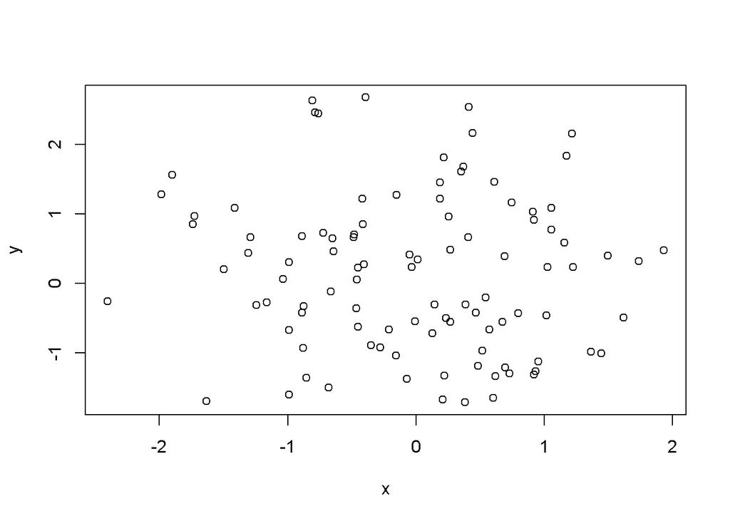

```r
plot(x,y)
```

##### Add Labels

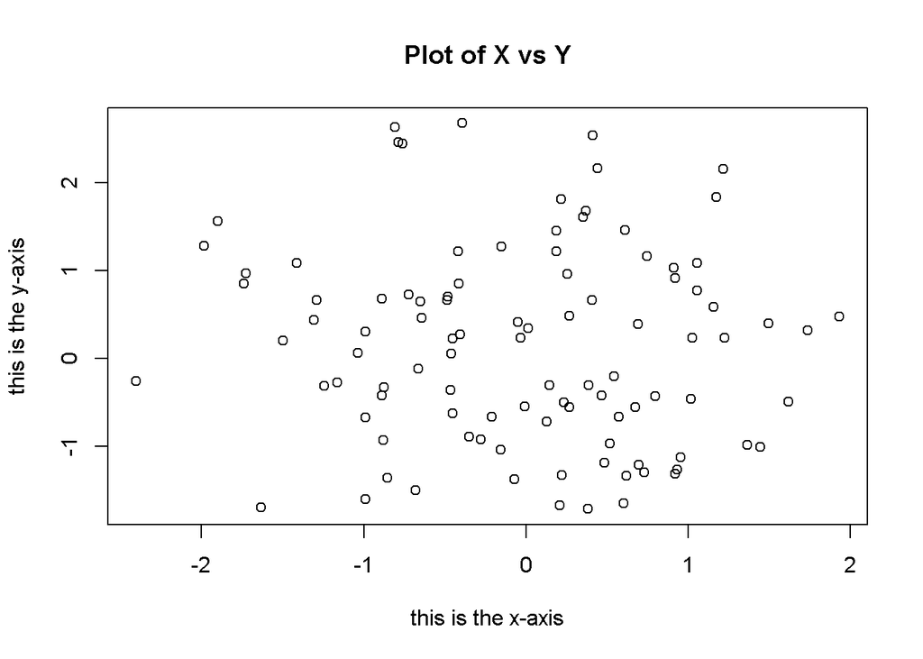

```r
plot(x,y,xlab="this is the x-axis",ylab="this is the y-axis",main="Plot of X vs Y")
```

##### Save as a pdf

###### `pdf("Figure.pdf")` would save the figure to the project directory. You must add a path to store it in the correct place. Make sure to use `dev.off()` when you are done with your plot specificaitons tp close the file.

```r
pdf("C:/Users/valer/OneDrive/Documents/Spring 2021/KM/Week 1/Figure.pdf")
plot(x,y,xlab="this is the x-axis",ylab="this is the y-axis",main="Plot of X vs Y")
dev.off()
```

###### You can change the color of the points. For example `plot(x,y,col="green")` will plot the points green.

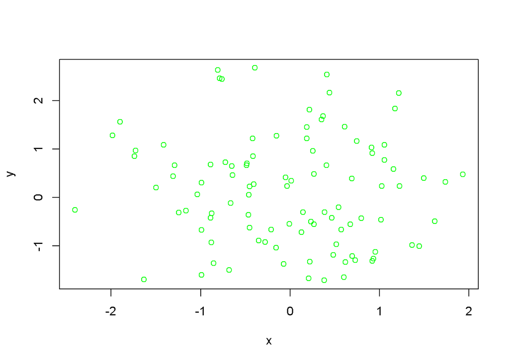

```r
plot(x,y,col="green")
```

### **Fancy Graphs: *contour, image, persp* (3D)**

##### Countour

###### I kept getting an error on this section when I tried to knit the markdown file so I changed the x and y values.

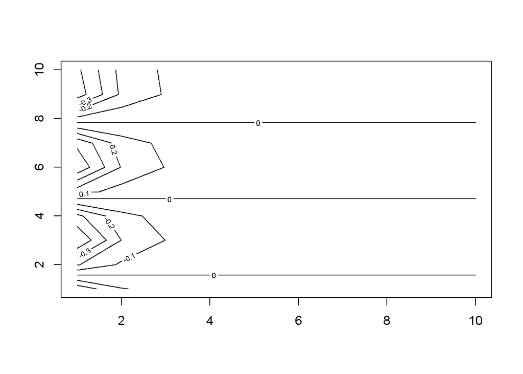

```r
x<-c(1:10)
y<-c(1:10)
z<-matrix(x,nrow=length(x),ncol=length(y))
f=outer(x,y, function(x,y)cos(y)/(1+x^2))
contour(x,y,f)
```

###### Adding more levels/lines

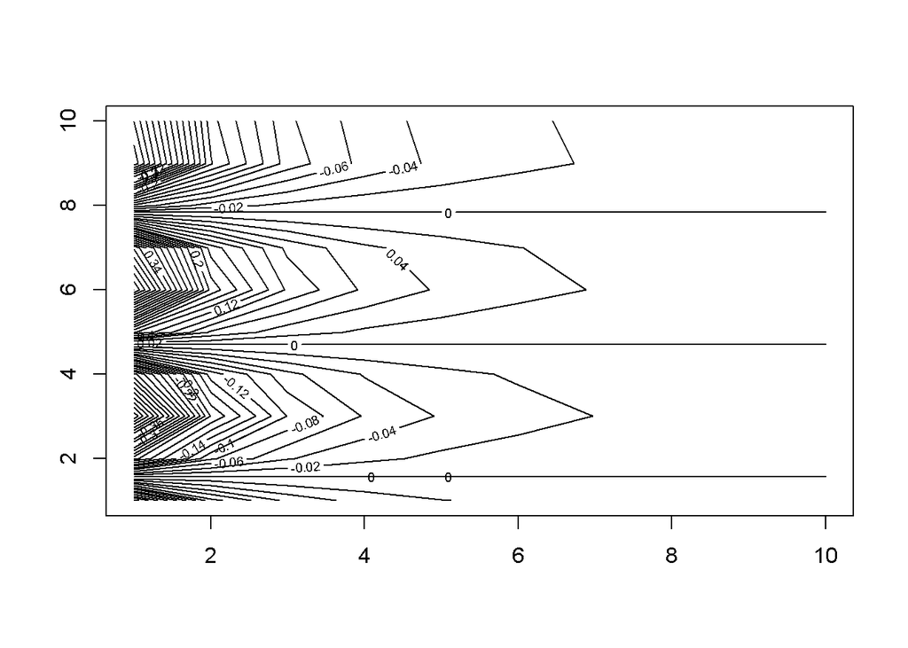

```r
f=outer(x,y,function(x,y)cos(y)/(1+x^2))
contour(x,y,f)
contour(x,y,f,nlevels=45,add=T)
```

##### Another contour example

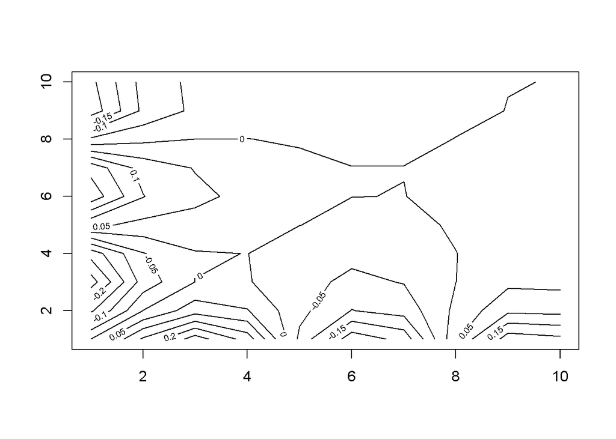

```r
fa=(f-t(f))/2
contour(x,y,fa,nlevels=15)
```

##### Image

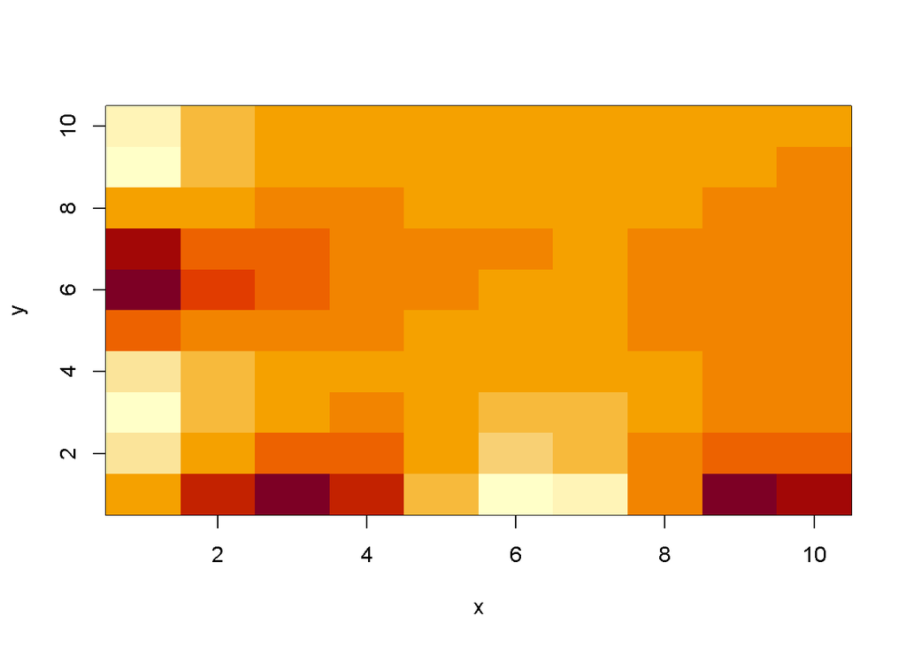

```r
image(x,y,fa)
```

##### 3D

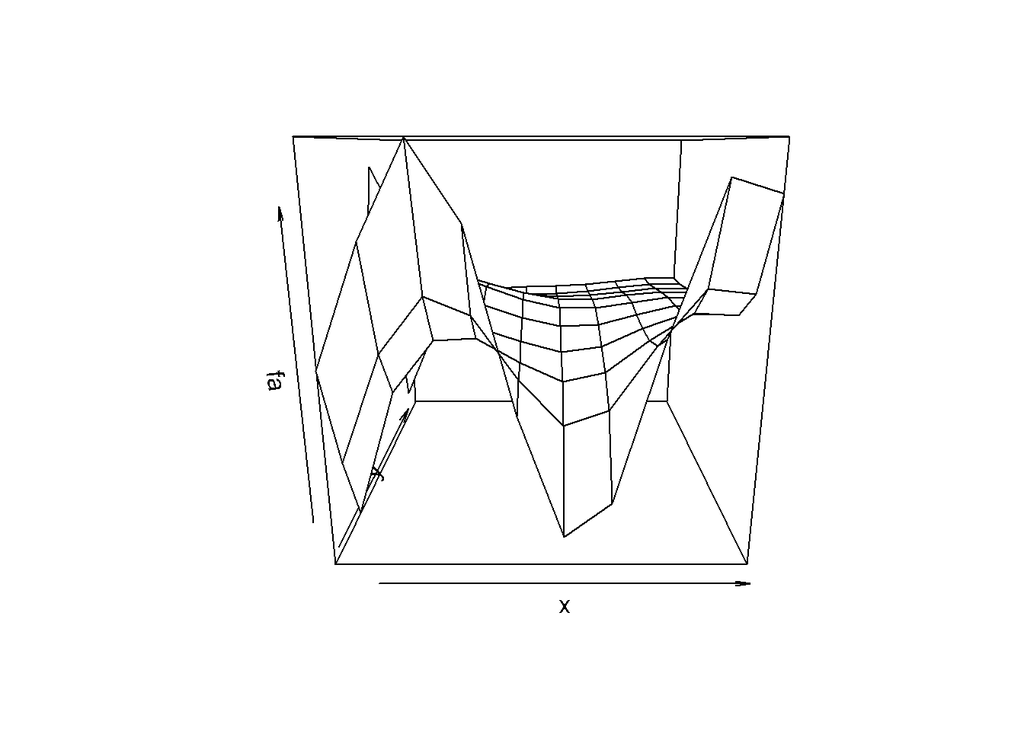

```r
persp(x,y,fa)
```

###### You can change the angle of the 3D graph by using `theta=` and `phi=`.

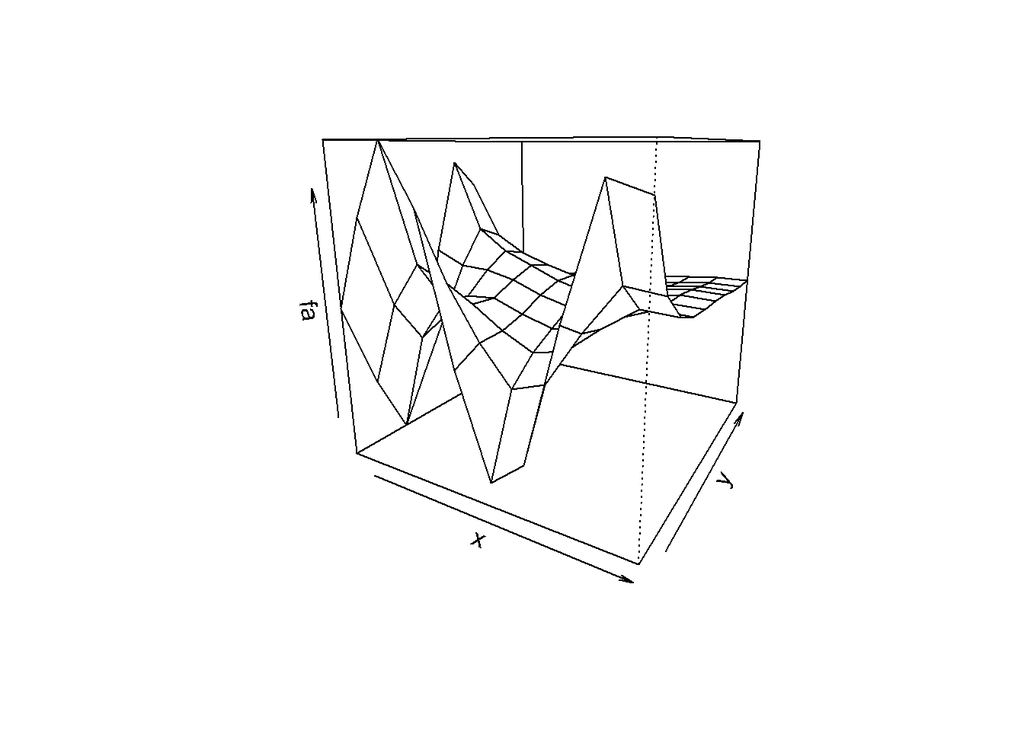

```r
persp(x,y,fa,theta=30)
```

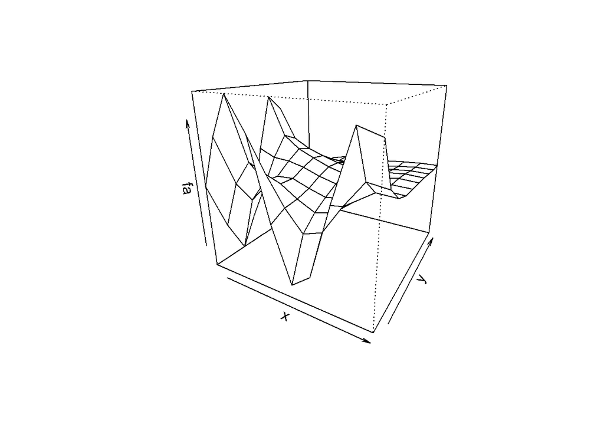

```r
persp(x,y,fa,theta=30,phi=20)
```

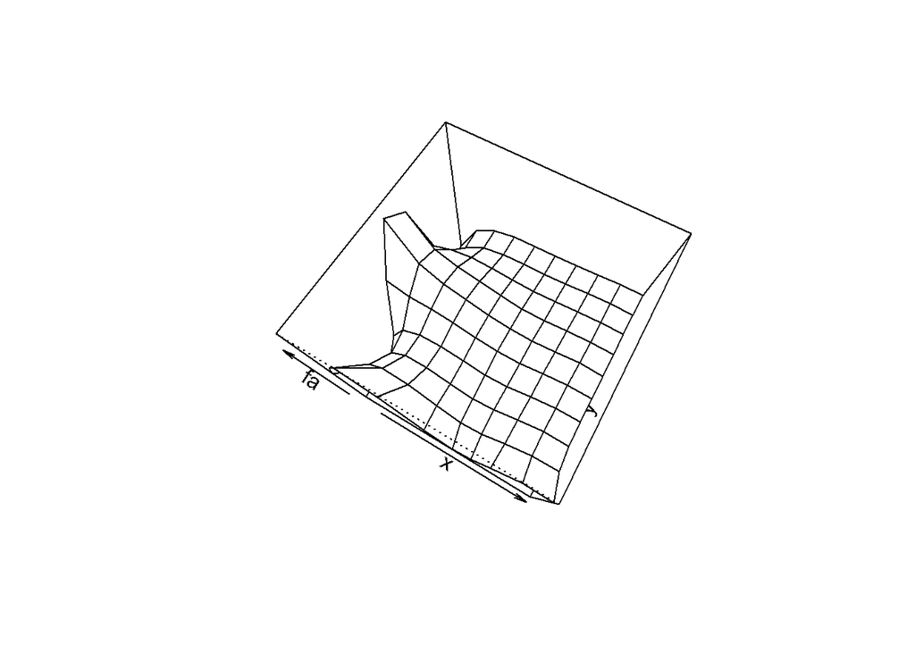

```r
persp(x,y,fa,theta=30,phi=70)
```

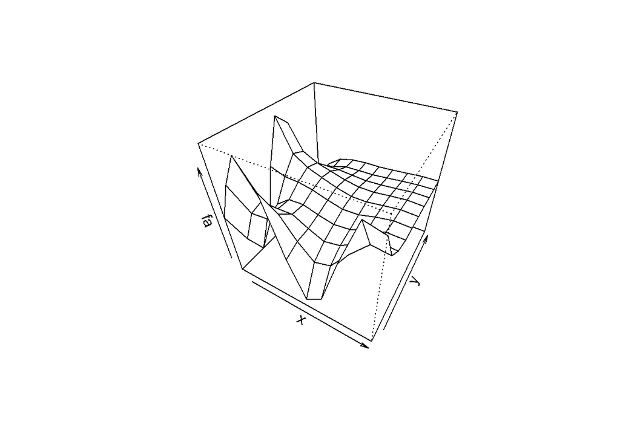

```r
persp(x,y,fa,theta=30,phi=40)
```